# STA237A Hw13

Eric Kalosa-Kenyon

14 November 2017

Abstract

In this assignment, I address spectral methods for time series models.

# Spectral density

Given the kernel $\gamma(h) = \frac{sin(ah)}{h}$, notice that it is positive semidefinite and thus a covariance function for a time series. The spectral density of the ACVF $\gamma(h)$ is

$$f(\lambda) = \frac{1}{2\pi} \sum_{j\in\mathbb{Z}}
e^{-ih\lambda} \gamma(h) =
\frac{1}{\pi}(\frac{a}{2} + \sum_{h=1}^{\infty}
\frac{sin(ah)cos(\lambda h)}{h})$$

Given the spectral density $f(\lambda) = (\pi-|\lambda|)\pi^{-2}$, the autocovariance function is
$$\gamma(h) = \int_{-\pi}^\pi e^{ih\lambda}\gamma(h) d\lambda =
\int_{-\pi}^\pi e^{ih\lambda}(\pi - |\lambda|)\pi^{-2} d\lambda =
\frac{1}{\pi^2} (
\int_{-\pi}^{\pi} \pi (\cos(h\lambda) + i\sin(h\lambda)) d\lambda -
\int_{-\pi}^\pi |\lambda| (\cos(h\lambda) + i\sin(h\lambda)) d\lambda
)$$

$$= \frac{2}{\pi} \int_{-\pi}^\pi \cos(h\lambda) d\lambda +
\frac{1}{\pi^2} (\int_{-\pi}^0 \lambda cis(h\lambda) d\lambda -
\int_0^\pi \lambda cis(h\lambda) d\lambda) =
\frac{2}{(\pi h)^2}(1-\cos(\pi h))$$

and when $h=0$ the ACVF $\gamma(0)=1$.

# Sunspots

The following graphs show the raw sunspot observations and their mean-corrected representation.

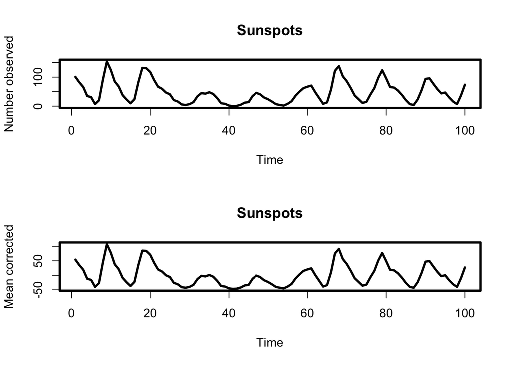

The following graphs display the ACF and PACF.

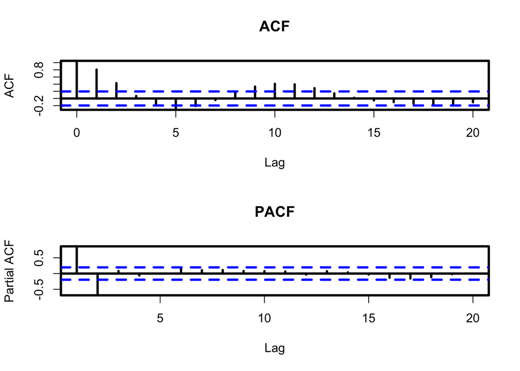

Based on the 2 significant, opposite legs on the PACF, AR(2) is appropriate. The oscilatory behavior of the ACF encourages the notion that $X_t = t_1 X_{t-1} + t_2 X_{t-2} + Z_t$, where $t_1>0$ and $t_2<0$. The following snippet fits such an AR(2) model to the data.

```r
par(lwd=3, mfrow=c(2,1))
m1 = arima(d$Y, c(2, 0, 0)) # p=2, d=q=0
m2 = ar(d$Y, 2) # different fit than m1
th = coefficients(m1)[1:2]
```

Indeed, as expected, $t_1=1.4075745$ and $t_2=-0.7128151$. Next, I simulate some data from the AR(2) as a visual sanity check.

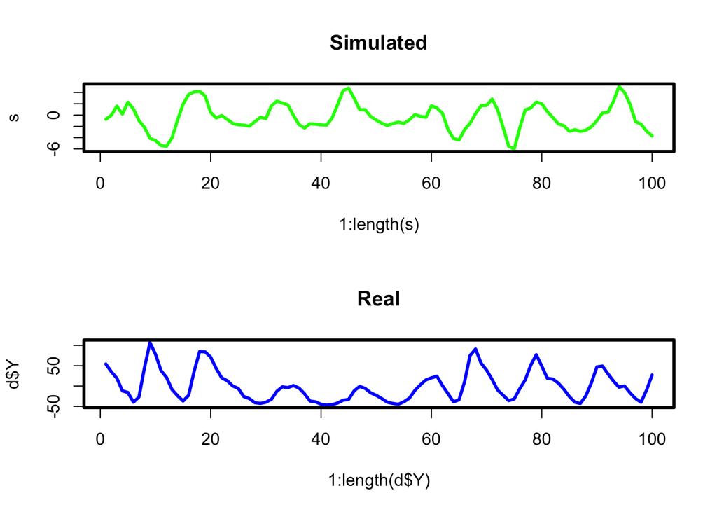

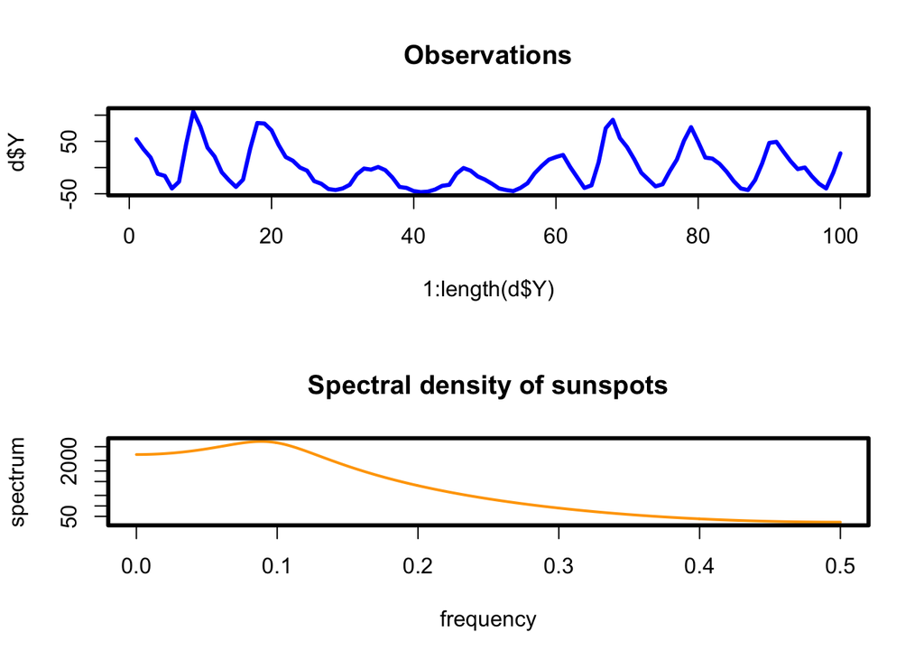

Notice that the maximal frequency is $0.0881764$ corresponding to a maximal period of $11.3409091$, that is, aproximately 12 months or one year. This encourages the notion that there are parts of the surface of the sun that have more sunspots than others, and that these portions of the sun’s surface are visible only for portions of the year.

# Power Transfer Function

Given a filter $\Psi$ with coefficients $\psi_0=1$, $\psi_1=-2\alpha$, and $\psi_2=1$; the power transfer function is

$$|\psi(e^{-ix})|^2 = |1-2\alpha e^{-ix} + e^{-2ix}|^2 =
4(\alpha-\cos(x))^2$$

To use this filter to suppress period 6 oscilations, I will force the spectral density to 0 at the frequency $\lambda=\frac{2\pi}{6}$, namely $\alpha = \cos(\frac{\pi}{3})$.

Applying the filter to the process
$$X_t = A\cos(\frac{t\pi}{3}) + b\sin(\frac{t\pi}{3}) + Z_t + 2.5Z_{t-1}$$
causes the trigonometric terms to cancel and yields
$$Y_t = \sum_{i=0}^2 \psi_i X_{t-i} =
Z_t + (2.5-2\alpha)Z_{t-1} + (1-5\alpha)Z_{t-2} + 2.5Z_{t-3}$$

To calculate the spectral density of this filtered time series, notice that $f_Y(\lambda) = |\psi(e^{-i\lambda})|^2 f_X(\lambda)$ by Theorem 4.2.4 in the notes. Hence, to calculate the spectral density of the filtered process, only the spectral density for the original process and the power transfer function are required.

$$\gamma(0) = \tau^2(\cos^2(\frac{t\pi}{3}) + \sin^2(\frac{t\pi}{3})) +
7.25\sigma^2 = \tau^2 + 7.25\sigma^2$$

Similarly,
$$\gamma(1) = \frac{\tau^2}{2} + 2.5\sigma^2 \quad\textrm{and}\quad
\gamma(h\ge 2) = \tau^2\cos(\frac{\pi h}{3})$$